# Do the frozen models know post-1929 US politics, or just complete the first name?

Battery: `2_model_probes/us_politics_power.py` (presidential succession + civil rights), scored two ways. **Cued** = the original prompt hands the model the first name (“… was Franklin ___” → Roosevelt). **No-cue** = the given name is stripped, so the description alone must yield the surname (“… who launched the New Deal was ___”). The gap is shallow name-completion; what survives no-cue is knowledge. Ranke 1913 & 1929; four-way forced choice, chance 25%.

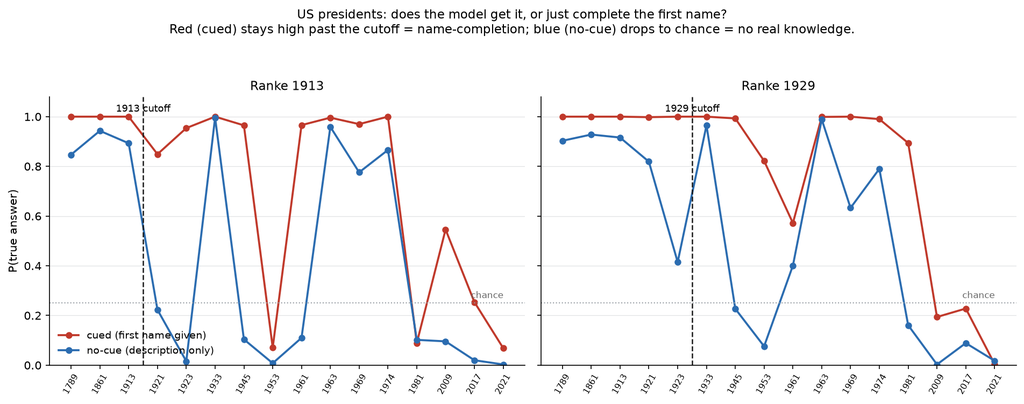

Left/right: the two models. Red line = cued P(true); blue = no-cue. Dashed vertical = that model’s training cutoff; dotted horizontal = chance. Red staying high past the cutoff is the first name doing the work; blue collapsing to chance is the absence of real knowledge.

## Presidential succession

| year | true | 1913 cued | 1913 no-cue | 1913 says (no-cue) | 1929 cued | 1929 no-cue | 1929 says (no-cue) |
| --- | --- | --- | --- | --- | --- | --- | --- |
| 1789 | Washington | 100% | 85% | John Adams, who had been | 100% | 90% | George Washington. He was born |
| 1861 | Lincoln | 100% | 94% | a man who had been in | 100% | 93% | Abraham Lincoln. He had been |
| 1913 | Wilson | 100% | 89% | a man of peace. He | 100% | 92% | asked to speak at a meeting |
| 1921 | Harding | 85% | 22% | the first to break his promise | 100% | 82% | not able to keep his promise |
| 1923 | Coolidge | 95% | 2% | elected. The new president is | 100% | 42% | elected. The Republican party had |
| 1933 | Roosevelt | 100% | 100% | a man of great courage and | 100% | 96% | a man of great ability and |
| 1945 | Truman | 96% | 10% | a member OF the Cabinet which | 99% | 23% | not a member Of that country |
| 1953 | Eisenhower | 7% | 1% | the first woman to hold that | 82% | 8% | a member of the Order. |
| 1961 | Kennedy | 97% | 11% | a man of great ability and | 57% | 40% | a native of New York. |
| 1963 | Johnson | 100% | 96% | elected, and the Speaker of | 100% | 99% | assassinated, and the Secretary |
| 1969 | Nixon | 97% | 78% | the same man who had been | 100% | 63% | a man of great ability and |
| 1974 | Ford | 100% | 87% | a Democrat. The Democratic Party | 99% | 79% | a Democrat, and the Democratic |
| 1981 | Reagan | 9% | 10% | the first to be chosen for | 89% | 16% | the first to be chosen for |
| 2009 | Obama | 55% | 10% | a Negro. The second American | 19% | 0% | a Negro. He is the |
| 2017 | Trump | 25% | 2% | a man who had been an | 23% | 9% | a man who had been an |
| 2021 | Biden | 7% | 0% | the first to be elected by | 0% | 2% | the first to be held under |

## Civil rights

| year | true | 1913 cued | 1913 no-cue | 1913 says (no-cue) | 1929 cued | 1929 no-cue | 1929 says (no-cue) |
| --- | --- | --- | --- | --- | --- | --- | --- |
| 1954 | Education (phrase; no name to strip) | 92% | 92% | Education, and the decision is | 97% | 97% | Education, 283 |
| 1955 | Parks | 17% | 28% | Mrs. Mary E. M | 22% | 19% | Mrs. Mary E. M |
| 1963 | King | 99% | 98% | not Mr.. Bryan, but | 100% | 98% | not only an American, but |
| 1964 | Act (phrase; no name to strip) | 55% | 55% | bill of Senator Tillman, | 90% | 90% | Act of 187 |
| 1968 | Kennedy | 70% | 52% | a man who had been elected | 83% | 56% | a man who had been an |
| 1968 | Memphis (phrase; no name to strip) | 39% | 39% | Madrid, and his body was | 61% | 61% | Paris, and his body thrown |

## Cohort means, P(true)

| cohort | 1913 cued | 1913 no-cue | 1929 cued | 1929 no-cue |
| --- | --- | --- | --- | --- |
| presidents ≤1913 (both should know) | 100% | 89% | 100% | 92% |
| presidents 1914–29 (only 1929) | 90% | 12% | 100% | 62% |
| presidents >1929 (neither should) | 63% | 37% | 70% | 40% |